# seattle-airbnb-analysis

### Q3.How does availability vary through out the year? Are more listings available during busy months?

```python
df_av = df_cal.drop(['listing_id','price'], axis = 1)
```

```python
df_av.head()
```

| date | available |
| --- | --- |
| 2016-01-04 | t |
| 2016-01-05 | t |
| 2016-01-06 | f |
| 2016-01-07 | f |
| 2016-01-08 | f |

```python
# .groupby(pd.Grouper(freq='M')).count()
df_av.shape
```

```
(1393570, 1)
```

```python
df_av.available.value_counts()
```

```
t    934542
f    459028
Name: available, dtype: int64
```

```python
groups = df_av.groupby('available')
```

```python
groups.size()
```

```
available
f    459028
t    934542
dtype: int64
```

```python
df_av.info()
```

```
<class 'pandas.core.frame.DataFrame'>
DatetimeIndex: 1393570 entries, 2016-01-04 to 2017-01-02
Data columns (total 1 columns):
 #   Column     Non-Null Count    Dtype
---  ------     --------------    -----
 0   available  1393570 non-null  object
dtypes: object(1)
memory usage: 21.3+ MB
```

```python
di = {'t': 1, 'f': 0}
df_av["available"].replace(di, inplace=True)
```

```python
df_av.info()
```

```
<class 'pandas.core.frame.DataFrame'>
DatetimeIndex: 1393570 entries, 2016-01-04 to 2017-01-02
Data columns (total 1 columns):
 #   Column     Non-Null Count    Dtype
---  ------     --------------    -----
 0   available  1393570 non-null  int64
dtypes: int64(1)
memory usage: 21.3 MB
```

```python
df_av1 = df_av.groupby(pd.Grouper(freq='M')).agg({'available': ['sum','count','mean']})
```

```python
df_av1.columns =   [ 'Available Listings',
            'Total Listings',
            'Percentage Availability']
```

```python
df_av1
```

| date | Available Listings | Total Listings | Percentage Availability |
| --- | --- | --- | --- |
| 2016-01-31 | 59239 | 106904 | 0.554133 |
| 2016-02-29 | 73321 | 110722 | 0.662208 |
| 2016-03-31 | 83938 | 118358 | 0.709187 |
| 2016-04-30 | 76037 | 114540 | 0.663847 |
| 2016-05-31 | 79971 | 118358 | 0.675670 |
| 2016-06-30 | 77244 | 114540 | 0.674384 |
| 2016-07-31 | 74222 | 118358 | 0.627097 |
| 2016-08-31 | 76347 | 118358 | 0.645051 |
| 2016-09-30 | 77246 | 114540 | 0.674402 |
| 2016-10-31 | 82438 | 118358 | 0.696514 |
| 2016-11-30 | 81780 | 114540 | 0.713986 |
| 2016-12-31 | 87061 | 118358 | 0.735573 |
| 2017-01-31 | 5698 | 7636 | 0.746202 |

```python
df_av1.index = df_av1.index.month
```

```python
df_av2 = (df_av1.groupby('date').agg({'Available Listings': np.sum, 'Total Listings':np.sum}))
```

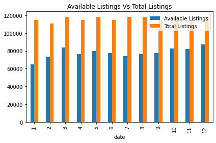

```python
df_av2.plot.bar(title="Available Listings Vs Total Listings")
plt.tight_layout()
plt.show()
```

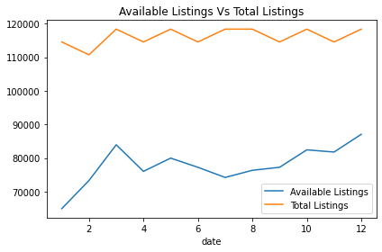

```python
df_av2.plot.line(title="Available Listings Vs Total Listings")
plt.tight_layout()
plt.show()
```

```python
df_av2
```

| date | Available Listings | Total Listings |
| --- | --- | --- |
| 1 | 64937 | 114540 |
| 2 | 73321 | 110722 |
| 3 | 83938 | 118358 |
| 4 | 76037 | 114540 |
| 5 | 79971 | 118358 |
| 6 | 77244 | 114540 |
| 7 | 74222 | 118358 |
| 8 | 76347 | 118358 |
| 9 | 77246 | 114540 |
| 10 | 82438 | 118358 |
| 11 | 81780 | 114540 |
| 12 | 87061 | 118358 |

- Listings peaked in March. From April till September available listings were more or less steady.
- Available Listings Peaked from October to December. This can probably be due to the beginning of the holiday season in November and December due to Thanks giving and Xmas.

```python
df_cal.drop(['listing_id','available'], inplace=True, axis = 1)
```

```python
df5 = df_cal.groupby(pd.Grouper(freq='M')).mean()
```

```python
df5.head()
```

| date | price |
| --- | --- |
| 2016-01-31 | 121.568409 |
| 2016-02-29 | 124.293927 |
| 2016-03-31 | 128.644488 |
| 2016-04-30 | 135.097005 |
| 2016-05-31 | 139.538183 |

```python
### Q3.
```

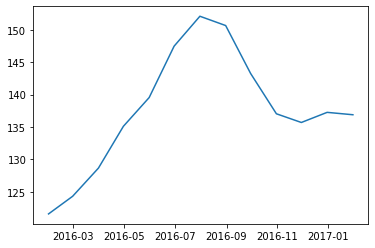

```python
fig = plt.figure()
ax = fig.add_subplot(1, 1, 1)
ax.plot(df5);
```

- July to September is Summer and we can see prices peak during these months

```python
df5.describe()
```

|  | price |
| --- | --- |
| count | 13.000000 |
| mean | 137.652073 |
| std | 9.304507 |
| min | 121.568409 |
| 25% | 135.097005 |
| 50% | 137.031939 |
| 75% | 143.255949 |
| max | 152.094150 |

```python
df_cal.min(), df_cal.max(), df_cal.count()
```

```
(price    10.0
 dtype: float64,
 price    1650.0
 dtype: float64,
 price    934542
 dtype: int64)
```

-- Let us drop outliers as they will affect the mean

```python
from scipy import stats
```

```python
df_cal
```

| date | price |
| --- | --- |
| 2016-01-04 | 85.0 |
| 2016-01-05 | 85.0 |
| 2016-01-06 | NaN |
| 2016-01-07 | NaN |
| 2016-01-08 | NaN |
| ... | ... |
| 2016-12-29 | NaN |
| 2016-12-30 | NaN |
| 2016-12-31 | NaN |
| 2017-01-01 | NaN |
| 2017-01-02 | NaN |

1393570 rows × 1 columns

```python
df_cal.dropna(inplace=True)
```

```python
df_cal_exc = df_cal[(np.abs(stats.zscore(df_cal['price'])) < 3)]
```

```python
df_cal_exc.head()
```

| date | price |
| --- | --- |
| 2016-01-04 | 85.0 |
| 2016-01-05 | 85.0 |
| 2016-01-13 | 85.0 |
| 2016-01-14 | 85.0 |
| 2016-01-18 | 85.0 |

```python
df_cal_exc.describe()
```

|  | price |
| --- | --- |
| count | 916749.000000 |
| mean | 128.529685 |
| std | 77.702854 |
| min | 10.000000 |
| 25% | 75.000000 |
| 50% | 105.000000 |
| 75% | 155.000000 |
| max | 453.000000 |

```python
df_cal.head()
```

| date | price |
| --- | --- |
| 2016-01-04 | 85.0 |
| 2016-01-05 | 85.0 |
| 2016-01-13 | 85.0 |
| 2016-01-14 | 85.0 |
| 2016-01-18 | 85.0 |

```python
df6 = df_cal_exc.groupby(pd.Grouper(freq='M')).mean()
```

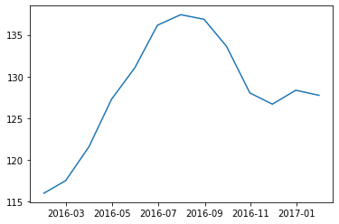

```python
fig = plt.figure()
ax = fig.add_subplot(1, 1, 1)
ax.plot(df6);
```

```python
df6.head(20) ### outliers removed
```

| date | price |
| --- | --- |
| 2016-01-31 | 116.000768 |
| 2016-02-29 | 117.510728 |
| 2016-03-31 | 121.579141 |
| 2016-04-30 | 127.269979 |
| 2016-05-31 | 131.044227 |
| 2016-06-30 | 136.143931 |
| 2016-07-31 | 137.411902 |
| 2016-08-31 | 136.861088 |
| 2016-09-30 | 133.609163 |
| 2016-10-31 | 128.026639 |
| 2016-11-30 | 126.681065 |
| 2016-12-31 | 128.347996 |
| 2017-01-31 | 127.741555 |

```python
df5.head(20)
```

| date | price |
| --- | --- |
| 2016-01-31 | 121.568409 |
| 2016-02-29 | 124.293927 |
| 2016-03-31 | 128.644488 |
| 2016-04-30 | 135.097005 |
| 2016-05-31 | 139.538183 |
| 2016-06-30 | 147.473137 |
| 2016-07-31 | 152.094150 |
| 2016-08-31 | 150.656594 |
| 2016-09-30 | 143.255949 |
| 2016-10-31 | 137.031939 |
| 2016-11-30 | 135.688738 |
| 2016-12-31 | 137.251835 |
| 2017-01-31 | 136.882590 |

```python
def get_monthly_price_quantiles(date_prices):
    """
        get monthly price quantiles and mean from date-prices
    """
    date_prices = date_prices.groupby(date_prices.index)
    monthly_prices = pd.concat([date_prices.quantile(q=0.25), date_prices.quantile(q=0.5), date_prices.mean(), date_prices.quantile(q=0.75)], axis=1)
    monthly_prices.columns = ["Q1", "median", "mean", "Q3"]

    return monthly_prices

monthly_price_quantiles = get_monthly_price_quantiles(df_cal_exc)
monthly_price_quantiles
```

| date | Q1 | median | mean | Q3 |
| --- | --- | --- | --- | --- |
| 2016-01-04 | 70.0 | 99.0 | 116.677344 | 140.00 |
| 2016-01-05 | 70.0 | 99.0 | 115.883180 | 139.00 |
| 2016-01-06 | 70.0 | 99.0 | 116.241570 | 140.00 |
| 2016-01-07 | 70.0 | 99.0 | 116.471023 | 140.00 |
| 2016-01-08 | 75.0 | 100.0 | 121.588403 | 150.00 |
| ... | ... | ... | ... | ... |
| 2016-12-29 | 75.0 | 103.0 | 129.199498 | 150.00 |
| 2016-12-30 | 79.0 | 110.0 | 134.887213 | 165.00 |
| 2016-12-31 | 79.0 | 110.0 | 135.493214 | 165.75 |
| 2017-01-01 | 75.0 | 104.0 | 128.307961 | 151.00 |
| 2017-01-02 | 75.0 | 100.0 | 127.147565 | 150.00 |

365 rows × 4 columns

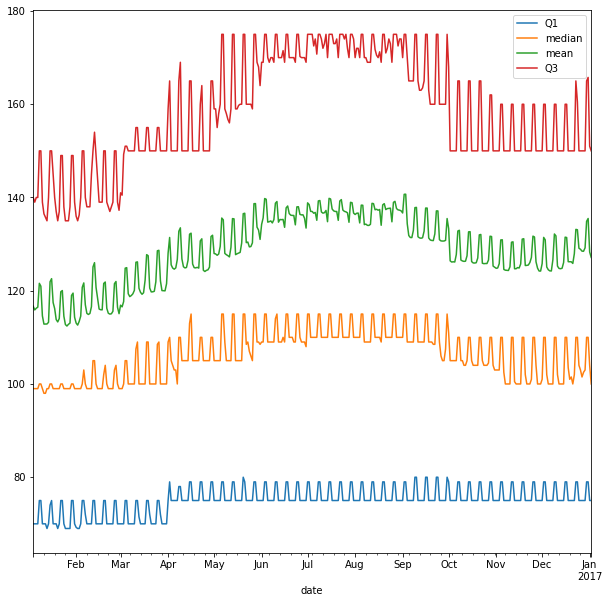

```python
def plot_line_monthly_prices_quantile(monthly_price_quantiles):
    """
        show bar plot the quantile, mean prices by month
    """
    monthly_price_quantiles.plot.line(figsize=(10, 10))

plot_line_monthly_prices_quantile(monthly_price_quantiles)
```

- Price in general is lowest till April and tends to peak from June to August
- Price of cheaper listings seems to be consistent across the year and does not change much
- Prices of listings in the 3rd quantile seem to be more affected by seasonal changes. In other words expensive listings are even more expensive during Summer months.

```python
#df_cal_exc.index = df_cal_exc.index.month_name()
df_cal_exc.index = df_cal_exc.index.month
```

```python
monthly_price_quantiles_n = get_monthly_price_quantiles(df_cal_exc)
monthly_price_quantiles_n
```

| date | Q1 | median | mean | Q3 |
| --- | --- | --- | --- | --- |
| 1 | 70.0 | 99.0 | 117.024339 | 145.0 |
| 2 | 71.5 | 100.0 | 117.510728 | 145.0 |
| 3 | 74.0 | 100.0 | 121.579141 | 150.0 |
| 4 | 75.0 | 109.0 | 127.269979 | 155.0 |
| 5 | 75.0 | 109.0 | 131.044227 | 163.0 |
| 6 | 75.0 | 110.0 | 136.143931 | 174.0 |
| 7 | 75.0 | 110.0 | 137.411902 | 175.0 |
| 8 | 75.0 | 110.0 | 136.861088 | 175.0 |
| 9 | 75.0 | 110.0 | 133.609163 | 168.0 |
| 10 | 75.0 | 105.0 | 128.026639 | 155.0 |
| 11 | 75.0 | 105.0 | 126.681065 | 150.0 |
| 12 | 75.0 | 105.0 | 128.347996 | 152.0 |

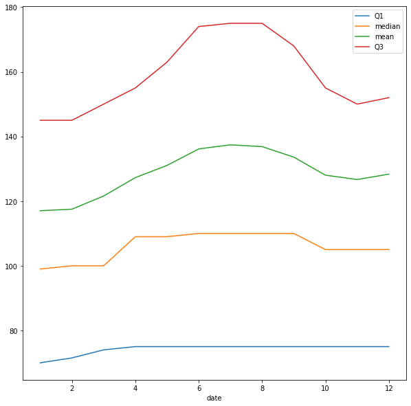

```python
plot_line_monthly_prices_quantile(monthly_price_quantiles_n)
```

### How does Price & Availability of listings vary over the year

- Price in general is lowest till April and tends to peak from June to August
- Price of cheaper listings seems to be consistent across the year and does not change much
- Prices of listings in the 3rd quantile seem to be more affected by seasonal changes. In other words expensive listings are even more expensive during Summer months.
- Listings peaked in March. From April till September available listings were more or less steady.
- Available Listings Peaked from October to December. This can probably be due to the beginning of the holiday season in November and December due to Thanks giving and Xmas.

### Q4. What property attributes have a high influence on price

- How well can we predict a listing price?
- What aspects correlate well to listing price?

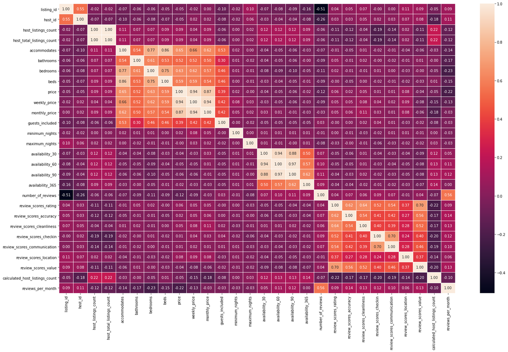

```python
fig, ax = plt.subplots(figsize=(25,15))
sns.heatmap(df_list.corr(), annot=True, fmt=".2f", linewidths=.5, ax=ax);
```

- Correlations related to bathrooms, accommodates, bedrooms, beds
  - The number of bedrooms, the number of bathrooms, and the number of beds have a high correlation with each other and a high correlation with price. It’s natural to think that the more rooms, beds, and toilets you have, the more expensive it becomes. However, the number of people was the most influential among them (0.65).
  - Whether or not a homestay can be rented for a long time has no significant correlation with other features other than each other.
  - The minimum and maximum stay dates are not significantly correlated with other features.
  - Currently we have not seen the influence of neighbourhood and property type on price. It would be interesting to see this correlation

```python
df_list.dtypes
```

```
listing_id                            int64
neighborhood_overview                object
host_id                               int64
host_name                            object
host_since                           object
host_response_time                   object
host_response_rate                   object
host_acceptance_rate                 object
host_is_superhost                    object
host_picture_url                     object
host_neighbourhood                   object
host_listings_count                 float64
host_total_listings_count           float64
host_verifications                   object
host_identity_verified               object
neighbourhood                        object
neighbourhood_cleansed               object
neighbourhood_group_cleansed         object
city                                 object
state                                object
zipcode                              object
is_location_exact                    object
property_type                        object
room_type                            object
accommodates                          int64
bathrooms                           float64
bedrooms                            float64
beds                                float64
bed_type                             object
amenities                            object
price                               float64
weekly_price                        float64
monthly_price                       float64
security_deposit                     object
cleaning_fee                         object
guests_included                       int64
extra_people                         object
minimum_nights                        int64
maximum_nights                        int64
calendar_updated                     object
```

[output cut: 8 more lines]

```
last_review                          object
review_scores_rating                float64
review_scores_accuracy              float64
review_scores_cleanliness           float64
review_scores_checkin               float64
review_scores_communication         float64
review_scores_location              float64
review_scores_value                 float64
requires_license                     object
instant_bookable                     object
cancellation_policy                  object
require_guest_phone_verification     object
calculated_host_listings_count        int64
reviews_per_month                   float64
dtype: object
```

```python
prop_price = 1 - df_list.isnull()['price'].mean()# Proportion of listings in the dataset with price

prop_price
```

```
1.0
```

```python
df_list[['listing_id', 'accommodates', 'bathrooms','bedrooms','beds','price']].describe()
```

|  | listing_id | accommodates | bathrooms | bedrooms | beds | price |
| --- | --- | --- | --- | --- | --- | --- |
| count | 3.818000e+03 | 3818.000000 | 3802.000000 | 3812.000000 | 3817.000000 | 3818.000000 |
| mean | 5.550111e+06 | 3.349398 | 1.259469 | 1.307712 | 1.735394 | 127.976166 |
| std | 2.962660e+06 | 1.977599 | 0.590369 | 0.883395 | 1.139480 | 90.250022 |
| min | 3.335000e+03 | 1.000000 | 0.000000 | 0.000000 | 1.000000 | 20.000000 |
| 25% | 3.258256e+06 | 2.000000 | 1.000000 | 1.000000 | 1.000000 | 75.000000 |
| 50% | 6.118244e+06 | 3.000000 | 1.000000 | 1.000000 | 1.000000 | 100.000000 |
| 75% | 8.035127e+06 | 4.000000 | 1.000000 | 2.000000 | 2.000000 | 150.000000 |
| max | 1.034016e+07 | 16.000000 | 8.000000 | 7.000000 | 15.000000 | 1000.000000 |

```python
df_list[['listing_id', 'accommodates', 'bathrooms','bedrooms','beds','price']].info()
```

```
<class 'pandas.core.frame.DataFrame'>
RangeIndex: 3818 entries, 0 to 3817
Data columns (total 6 columns):
 #   Column        Non-Null Count  Dtype
---  ------        --------------  -----
 0   listing_id    3818 non-null   int64
 1   accommodates  3818 non-null   int64
 2   bathrooms     3802 non-null   float64
 3   bedrooms      3812 non-null   float64
 4   beds          3817 non-null   float64
 5   price         3818 non-null   float64
dtypes: float64(4), int64(2)
memory usage: 179.1 KB
```

```python
## drop nulls
all_rm = df_list[['listing_id', 'accommodates', 'bathrooms','bedrooms','beds','price']].dropna(axis=0) # dataframe with rows for nan Salaries removed

all_rm.head()
```

|  | listing_id | accommodates | bathrooms | bedrooms | beds | price |
| --- | --- | --- | --- | --- | --- | --- |
| 0 | 241032 | 4 | 1.0 | 1.0 | 1.0 | 85.0 |
| 1 | 953595 | 4 | 1.0 | 1.0 | 1.0 | 150.0 |
| 2 | 3308979 | 11 | 4.5 | 5.0 | 7.0 | 975.0 |
| 3 | 7421966 | 3 | 1.0 | 0.0 | 2.0 | 100.0 |
| 4 | 278830 | 6 | 2.0 | 3.0 | 3.0 | 450.0 |

```python
all_rm.shape
```

```
(3796, 6)
```

```python
df_list[['neighbourhood_cleansed', 'listing_id', 'host_response_time']].info()
```

```
<class 'pandas.core.frame.DataFrame'>
RangeIndex: 3818 entries, 0 to 3817
Data columns (total 3 columns):
 #   Column                  Non-Null Count  Dtype
---  ------                  --------------  -----
 0   neighbourhood_cleansed  3818 non-null   object
 1   listing_id              3818 non-null   int64
 2   host_response_time      3295 non-null   object
dtypes: int64(1), object(2)
memory usage: 89.6+ KB
```

```python
dummy_var_df = df_list[['neighbourhood_cleansed', 'listing_id', 'host_response_time']]
```

```python
pd.get_dummies(dummy_var_df['host_response_time'])
```

|  | a few days or more | within a day | within a few hours | within an hour |
| --- | --- | --- | --- | --- |
| 0 | 0 | 0 | 1 | 0 |
| 1 | 0 | 0 | 0 | 1 |
| 2 | 0 | 0 | 1 | 0 |
| 3 | 0 | 0 | 0 | 0 |
| 4 | 0 | 0 | 0 | 1 |
| ... | ... | ... | ... | ... |
| 3813 | 0 | 0 | 1 | 0 |
| 3814 | 0 | 0 | 0 | 1 |
| 3815 | 0 | 0 | 0 | 0 |
| 3816 | 0 | 0 | 0 | 1 |
| 3817 | 0 | 1 | 0 | 0 |

3818 rows × 4 columns

```python
pd.get_dummies(dummy_var_df['neighbourhood_cleansed'])
```

|  | Adams | Alki | Arbor Heights | Atlantic | Belltown | Bitter Lake | Briarcliff | Brighton | Broadview | Broadway | Bryant | Cedar Park | Central Business District | Columbia City | Crown Hill | Dunlap | East Queen Anne | Eastlake | Fairmount Park | Fauntleroy | First Hill | Fremont | Gatewood | Genesee | Georgetown | Green Lake | Greenwood | Haller Lake | Harrison/Denny-Blaine | … |
| --- | --- | --- | --- | --- | --- | --- | --- | --- | --- | --- | --- | --- | --- | --- | --- | --- | --- | --- | --- | --- | --- | --- | --- | --- | --- | --- | --- | --- | --- | --- |
| 0 | 0 | 0 | 0 | 0 | 0 | 0 | 0 | 0 | 0 | 0 | 0 | 0 | 0 | 0 | 0 | 0 | 0 | 0 | 0 | 0 | 0 | 0 | 0 | 0 | 0 | 0 | 0 | 0 | 0 | … |
| 1 | 0 | 0 | 0 | 0 | 0 | 0 | 0 | 0 | 0 | 0 | 0 | 0 | 0 | 0 | 0 | 0 | 0 | 0 | 0 | 0 | 0 | 0 | 0 | 0 | 0 | 0 | 0 | 0 | 0 | … |
| 2 | 0 | 0 | 0 | 0 | 0 | 0 | 0 | 0 | 0 | 0 | 0 | 0 | 0 | 0 | 0 | 0 | 0 | 0 | 0 | 0 | 0 | 0 | 0 | 0 | 0 | 0 | 0 | 0 | 0 | … |
| 3 | 0 | 0 | 0 | 0 | 0 | 0 | 0 | 0 | 0 | 0 | 0 | 0 | 0 | 0 | 0 | 0 | 0 | 0 | 0 | 0 | 0 | 0 | 0 | 0 | 0 | 0 | 0 | 0 | 0 | … |
| 4 | 0 | 0 | 0 | 0 | 0 | 0 | 0 | 0 | 0 | 0 | 0 | 0 | 0 | 0 | 0 | 0 | 0 | 0 | 0 | 0 | 0 | 0 | 0 | 0 | 0 | 0 | 0 | 0 | 0 | … |
| ... | ... | ... | ... | ... | ... | ... | ... | ... | ... | ... | ... | ... | ... | ... | ... | ... | ... | ... | ... | ... | ... | ... | ... | ... | ... | ... | ... | ... | ... | … |
| 3813 | 0 | 0 | 0 | 0 | 0 | 0 | 0 | 0 | 0 | 0 | 0 | 0 | 0 | 0 | 0 | 0 | 0 | 0 | 0 | 0 | 0 | 1 | 0 | 0 | 0 | 0 | 0 | 0 | 0 | … |
| 3814 | 0 | 0 | 0 | 0 | 0 | 0 | 0 | 0 | 0 | 0 | 0 | 0 | 0 | 0 | 0 | 0 | 0 | 0 | 0 | 0 | 0 | 0 | 0 | 0 | 0 | 0 | 0 | 0 | 0 | … |
| 3815 | 0 | 0 | 0 | 0 | 0 | 0 | 0 | 0 | 0 | 0 | 0 | 0 | 0 | 0 | 0 | 0 | 0 | 0 | 0 | 0 | 0 | 0 | 0 | 0 | 0 | 0 | 0 | 0 | 0 | … |
| 3816 | 0 | 0 | 0 | 0 | 0 | 0 | 0 | 0 | 0 | 0 | 0 | 0 | 0 | 0 | 0 | 0 | 0 | 0 | 0 | 0 | 0 | 0 | 0 | 0 | 0 | 0 | 0 | 0 | 0 | … |
| 3817 | 0 | 0 | 0 | 0 | 0 | 0 | 0 | 0 | 0 | 0 | 0 | 0 | 0 | 0 | 0 | 0 | 1 | 0 | 0 | 0 | 0 | 0 | 0 | 0 | 0 | 0 | 0 | 0 | 0 | … |

3818 rows × 87 columns

```python
pd.get_dummies(dummy_var_df['neighbourhood_cleansed']).shape
```

```
(3818, 87)
```

```python
def clean_data(df):
    '''
    INPUT
    df - pandas dataframe

    OUTPUT
    X - A matrix holding all of the variables you want to consider when predicting the response
    y - the corresponding response vector

    Perform to obtain the correct X and y objects
    This function cleans df using the following steps to produce X and y:
    1. Select the numeric variables in the dataset
    2. Imputes the mean to fill null values for numeric variables
    3. Select the categorical variables
    4. Creates dummy columns for the categorical variables
    5. Create X as all the columns that are not the Price column
    6. Create y as the Price column

    '''

    ### dfmi.loc[:, ('one', 'second')]
    num_vars= df.select_dtypes(include=['int','float']).columns


    for var in num_vars:
        df[var].fillna((df[var].mean()), inplace=True)


    cat_vars = df.select_dtypes(include=['object']).columns


    for var in cat_vars:
        # for each cat add dummy var, drop original column
        df = pd.concat([df.drop(var, axis=1), pd.get_dummies(df[var], prefix=var, prefix_sep='_', drop_first=True)], axis=1)


    #X = df.drop(columns=['price'], axis=1)
    #y = df['price']

    #return X, y
    return df
```

```python
filtered_df = df_list[[ "host_is_superhost","host_listings_count", "neighbourhood_cleansed", "property_type","room_type", "accommodates", "bathrooms", "bedrooms",
               "beds", "price", "number_of_reviews", "review_scores_rating", "cancellation_policy",
               "reviews_per_month"]]

# X_new, y_new = clean_data(filtered_df)

newdf = clean_data(filtered_df)
```

```python
X_new = newdf.drop(['price'],axis=1)
y_new = newdf['price']
```

## 4.Modeling

```python
# Consider only numerical variables
X = all_rm[['accommodates', 'bathrooms','bedrooms','beds']]

y = all_rm['price']
```

```python
X_train, X_test, y_train, y_test = train_test_split(X, y, test_size = .30, random_state=42)
```

```python
#Instantiate
lm_model = LinearRegression(normalize=True)
```

```python
#Fit
lm_model.fit(X_train, y_train)
```

```
LinearRegression(normalize=True)
```

## 5.Results and Evaluation

The r-squared score measures for relative goodness-of-fit.

RMSE is an absolute measure of fit. It's useful since it is measured in the same units as the dependent variable. It is a simple loss function that we seek to minimize (without overfitting).

```python
#Predict and score the model
y_train_preds = lm_model.predict(X_train)
print("The r-squared score for your model on the training data was {} on {} values. The RMSE was {}".format(r2_score(y_train, y_train_preds), len(y_train), mean_squared_error(y_train, y_train_preds)))
y_test_preds = lm_model.predict(X_test)
print("The r-squared score for your model on the test data was {} on {} values.  The RMSE was {}".format(r2_score(y_test, y_test_preds), len(y_test), mean_squared_error(y_test, y_test_preds)))
```

[output not shown]

R-squared is a measure of how well a linear regression model “fits” a dataset. Also commonly called the coefficient of determination, R-squared is the proportion of the variance in the response variable that can be explained by the predictor variable.

The value for R-squared can range from 0 to 1. A value of 0 indicates that the response variable cannot be explained by the predictor variable at all. A value of 1 indicates that the response variable can be perfectly explained without error by the predictor variable.

If your main objective is to predict the value of the response variable accurately using the predictor variable, then R-squared is important.

In general, the larger the R-squared value, the more precisely the predictor variables are able to predict the value of the response variable.

The root-mean-squared error (RMSE) is a measure of how well your model performed. It does this by measuring difference between predicted values and the actual values.

In a good model, the RMSE should be close for both your testing data and your training data. If the RMSE for your testing data is higher than the training data, there is a high chance that your model overfit. In other words, your model performed worse during testing than training.

In general, RMSE is a commonly used metric and serves well as a general purpose error metric.

Other metrics include:

- Absolute Error
- Mean Absolute Error
- Mean Squared Error

## 6.Modeling with additional features

```python
X_train_new, X_test_new, y_train_new, y_test_new = train_test_split(X_new, y_new, test_size = .40, random_state=42)
#Instantiate
lm_model = LinearRegression(normalize=True)
#Fit
lm_model.fit(X_train_new, y_train_new)
```

```
LinearRegression(normalize=True)
```

```python
#Predict and score the model
y_train_preds_new = lm_model.predict(X_train_new)
print("The r-squared score for your model on the training data was {} on {} values. The RMSE was {}".format(r2_score(y_train_new, y_train_preds_new), len(y_train_new), mean_squared_error(y_train_new, y_train_preds_new)))
y_test_preds_new = lm_model.predict(X_test_new)
print("The r-squared score for your model on the test data was {} on {} values.  The RMSE was {}".format(r2_score(y_test_new, y_test_preds_new), len(y_test), mean_squared_error(y_test_new, y_test_preds_new)))
```

[output not shown]

## 7.Conclusion

Based on our analysis we can draw the below conclusions

- Listings peaked in March. From April till September available listings were more or less steady.
- Available Listings Peaked from October to December. This can probably be due to the beginning of the holiday season in November and December due to Thanks giving and Xmas.
- Listing prices peak in Summer months but the prices of already low-priced listings tend to not change much through out the year.
- Listing price has a strong correlation with number of bedrooms, the number of bathrooms, and the number of beds have a high correlation with each other and a high correlation with price. It’s natural to think that the more rooms, beds, and toilets you have, the more expensive it becomes. However, the number of people a property could accomodate had a high influence on price.
- We were then able to build a linear regession model to predict the list price based on quantitative variables like number of bedrooms, the number of bathrooms, and the number of beds etc.
- Finally we were to improve this model by adding some more features by including categorical variables like neighbourhood, property type, cancellation policy etc.